# Bipolar Disorder & Suicidality Risk Group Cluster Stability Analysis

Sam A. Sievertsen

2025-11-14

## Compute Stability of Specified Cluster Solution

To note, higher Rand and Jaccard values (i.e., closer to 1.0) indicate more stable, reproducible clustering solutions

[output not shown]

[output cut: 945 more lines]

[output not shown]

Bootstrap stability summary (scaling=z_score, k=2, B=1000)

| k | boots | overall_Rand | overall_Jacc | mean_Rand | mean_Jacc | sd_Rand | sd_Jacc | q05_Rand | q95_Rand | q05_Jacc | q95_Jacc |
| --- | --- | --- | --- | --- | --- | --- | --- | --- | --- | --- | --- |
| 2 | 1000 | 0.982 | 0.977 | 0.982 | 0.977 | 0.018 | 0.024 | 0.945 | 0.997 | 0.928 | 0.996 |

## Plot Results of Stability Analysis

The following plots visualize the distribution and consistency of clustering stability metrics derived from bootstrap resampling (with replacement). The density plots with rug marks show the distribution of Rand and Jaccard indices across bootstrap samples, with reference lines indicating overall and mean values-higher, more concentrated distributions near 1.0 suggest stable clustering

The violin-boxplot compares the two stability metrics side-by-side, revealing their central tendencies and variability

The empirical cumulative distribution functions (ECDF) illustrate the probability that stability values fall below given thresholds, with steeper curves at higher values indicating better stability

Finally ,the scatter plot with density contours examines the correlation between Rand and Jaccard indices across bootstrap iterations, helping assess whether both metrics agree on clustering quality

Together, these visualizations provide some decent empirical visualizations for evaluating whether the chosen clustering solution produces consistent, reproducible partitions across resampled data

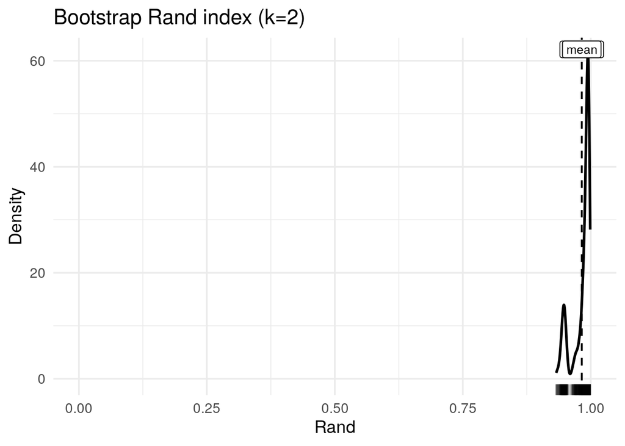

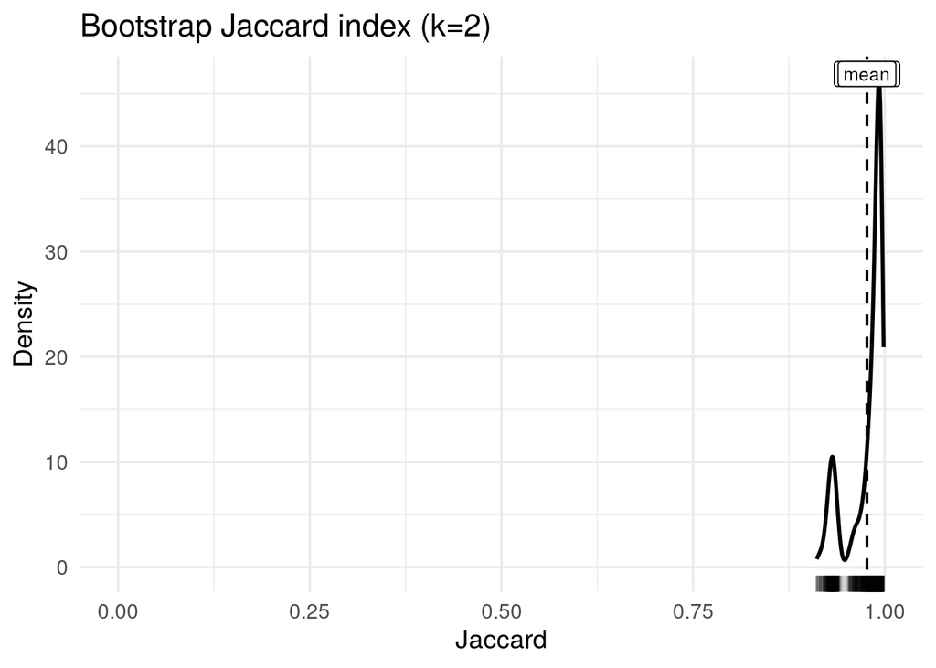

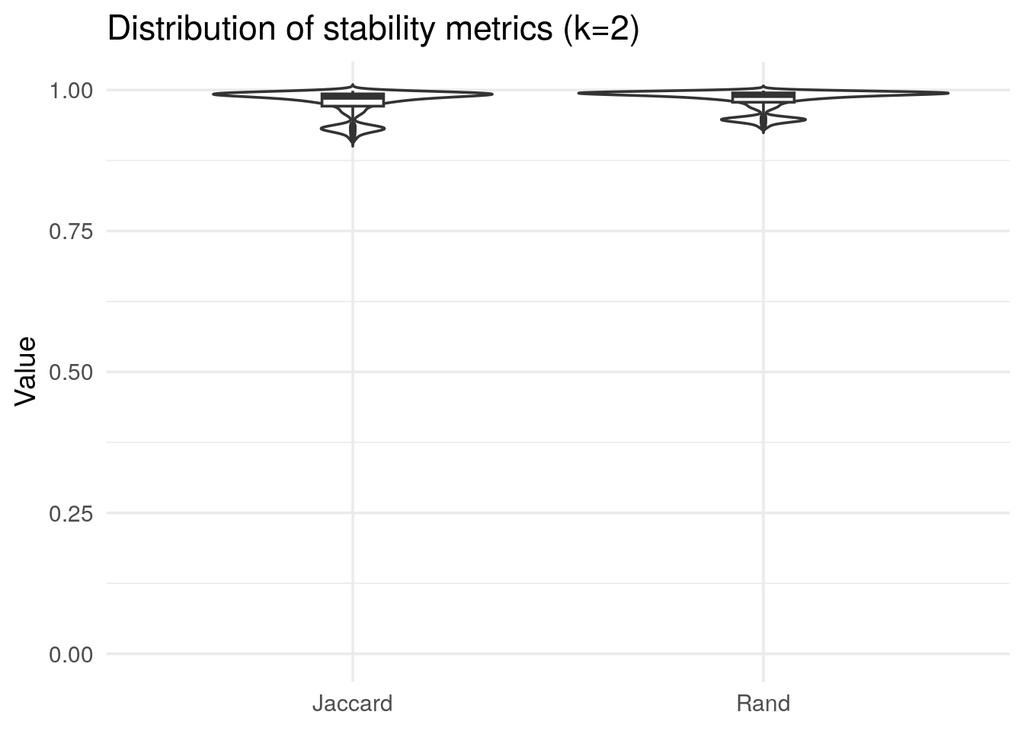

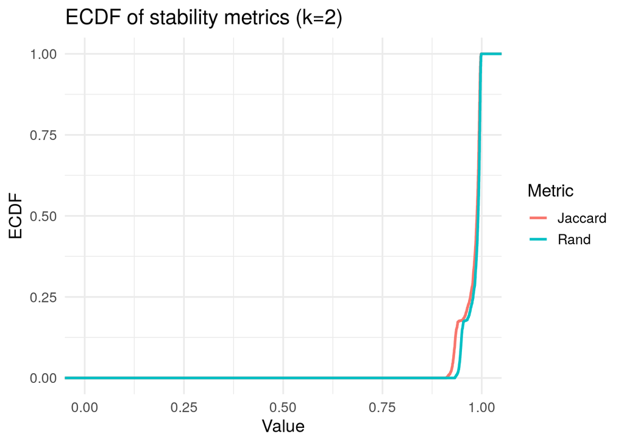

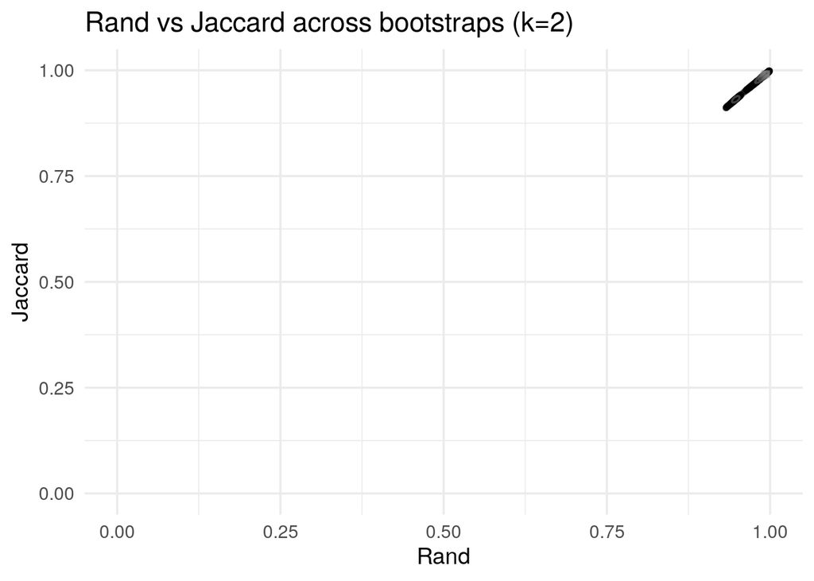